title: “Untitled” author: “Талапов Н./Абдулина Л.”

# 1 задание

# Сгенерируйте 200 случайных значений из стандартного экспоненциального распределения и сохраните в вектор exp.1. Найдите среднее и стандартное отклонение из данных этого вектора.

```r
rexp(n=200)->exp.1
mean(exp.1)->T
sd(exp.1)->A
```

Повторите, использовав следующие значения параметра 0.1, 0.5, 5, 10, и сохраните результаты в векторы: exp.0.1, exp.0.5, exp.5, exp.10.

значение параметра 0.1

```r
rexp(n=200, rate=0.1)->exp.0.1
mean(exp.0.1)->T1
sd(exp.0.1)->A1
```

значение параметра 0.5

```r
rexp(n=200, rate=0.5)->exp.0.5
mean(exp.0.5)->T2
sd(exp.0.5)->A2
```

значение параметра 5

```r
rexp(n=200, rate=5)->exp.5
mean(exp.5)->T3
sd(exp.5)->A4
```

значение параметра 10

```r
rexp(n=200, rate=10)->exp.10
mean(exp.10)->T4
sd(exp.10)->A4
```

# Функция plot() общая функция для визуализации данных. Функция hist() принимает данные и раскладывает их по корзинам. Чтобы использовать эти функции нужно для начала передать им данные, которые хотим визуализировать.

Используйте функцию hist() для построения гистограммы полученного ранее стандартного распределения.

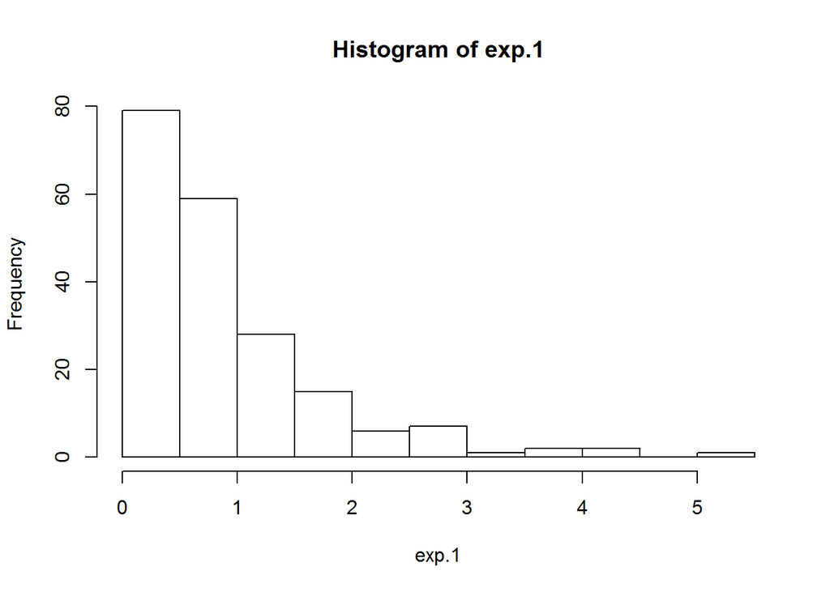

```r
hist(exp.1)
```

Используйте функцию plot() с тем же самым вектором для построения графика значений в порядке следования.

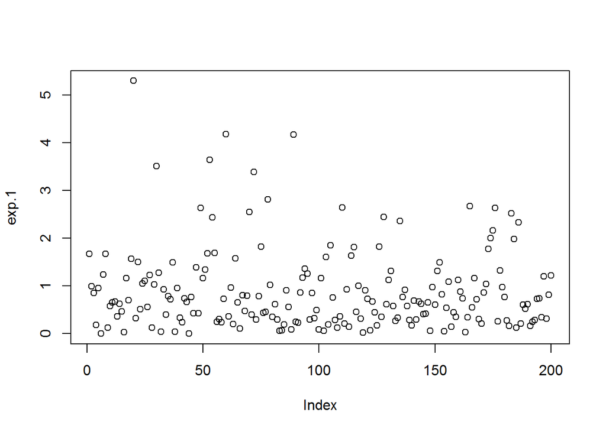

```r
plot(exp.1)
```

Используйте функцию plot() с любыми двумя полученными ранее векторами, чтобы получить диаграмму рассеяния этих векторов относительно друг друга.

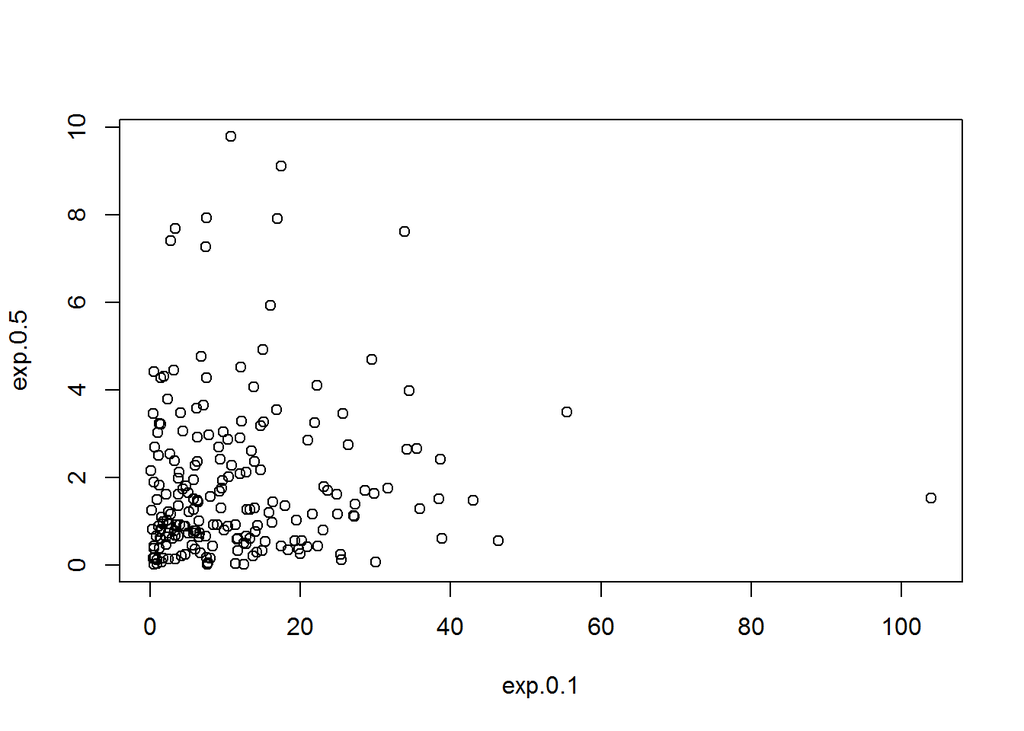

```r
plot(exp.0.1,exp.0.5)
```

# Теперь сравним свойства всех наших векторов. Для начала создадим вектор, содержащий средние значения каждого из 5 полученных ранее распределений в порядке их создания. Полученный вектор сохраним в переменную exp.means.

```r
exp.means=c(T,T1,T2,T3,T4)
```

создаём диаграммы рассеяния:

1. Вектор с пятью средними относительно каждого из пяти векторов с различными значениями;

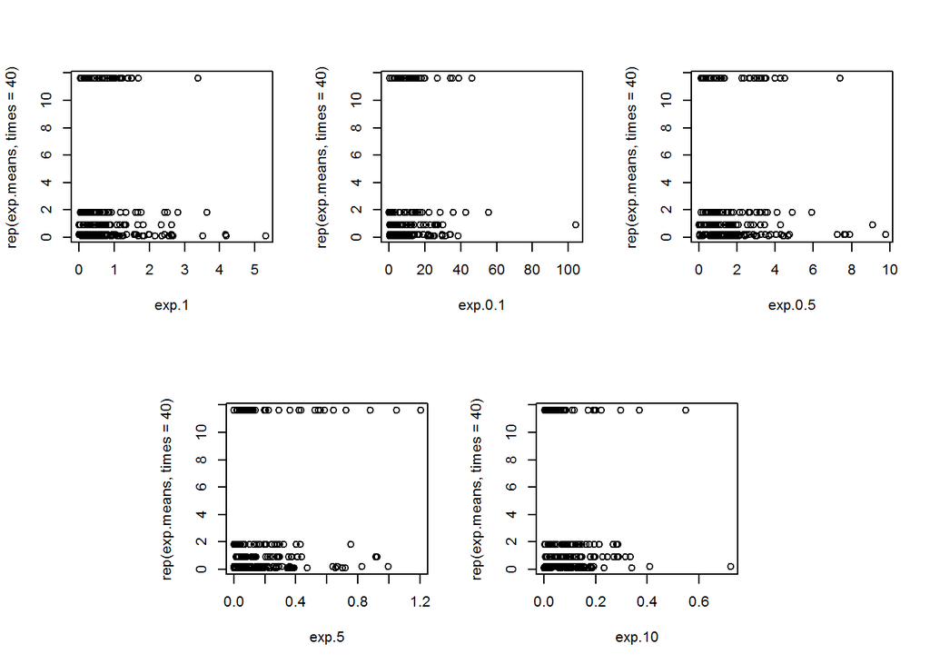

```r
layout(mat=matrix(c(1,1,2,2,3,3,0,4,4,5,5,0), nrow = 2, byrow=TRUE))
plot(exp.1, rep(exp.means, times = 40))
plot(exp.0.1, rep(exp.means, times = 40))
plot(exp.0.5, rep(exp.means, times = 40))
plot(exp.5, rep(exp.means, times = 40))
plot(exp.10, rep(exp.means, times = 40))
```

2)Вектор с пятью стандартными отклонениями относительно каждого из пяти векторов с различными значениями

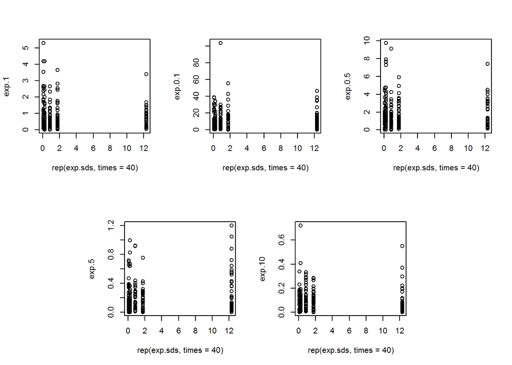

```r
layout(mat=matrix(c(1,1,2,2,3,3,0,4,4,5,5,0), nrow = 2, byrow=TRUE))
exp.sds = c(sd(exp.1),sd(exp.0.1),sd(exp.0.5),sd(exp.5),sd(exp.10))
plot(rep(exp.sds,times = 40),exp.1)
plot(rep(exp.sds,times = 40),exp.0.1)
plot(rep(exp.sds,times = 40),exp.0.5)
plot(rep(exp.sds,times = 40),exp.5)
plot(rep(exp.sds,times = 40),exp.10)
```

3)Вектор с пятью средними относительно вектора с пятью стандартными отклонениями

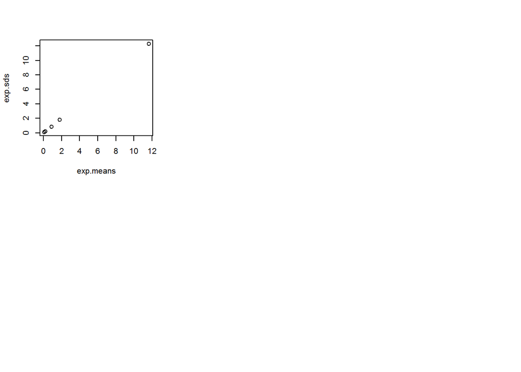

```r
layout(mat=matrix(c(1,1,2,2,3,3,0,4,4,5,5,0), nrow = 2, byrow=TRUE))
plot(exp.means,exp.sds)
```

# 2 задание

Для демонстрации сгенерируйте 1100000 (1 млн. 100 тысяч) чисел из стандартного экспоненциального распределения и сохраните их в вектор huge.exp.1. Получите среднее и стандартное отклонение.

```r
rexp(n=1100000)->huge.exp.1
mean(huge.exp.1)
```

```
## [1] 0.9999804
```

```r
sd(huge.exp.1)
```

```
## [1] 0.9999731
```

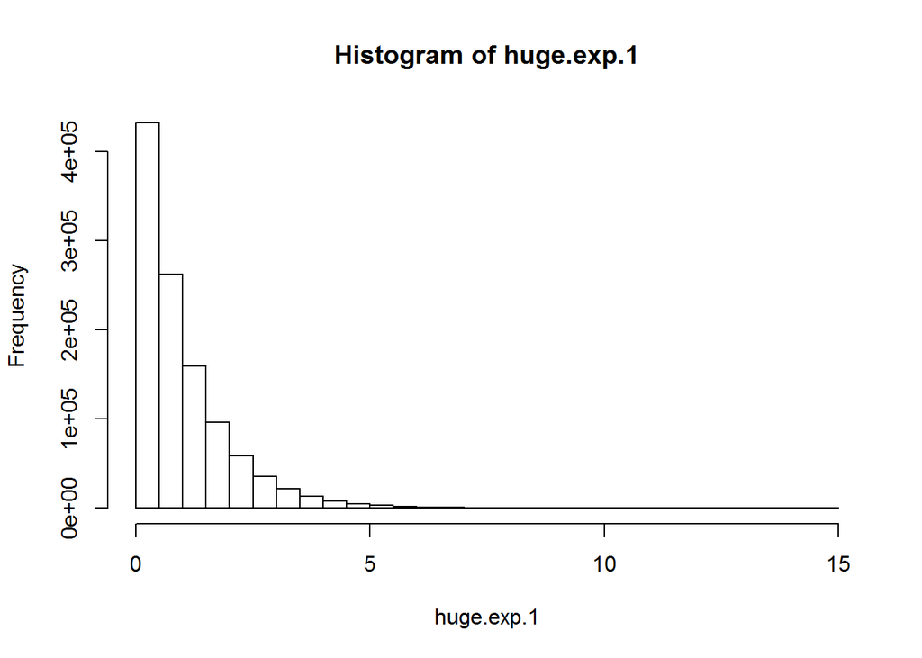

```r
hist(huge.exp.1)
```

Получите среднее всех чисел из huge.exp.1 строго больших 1. Для проверки выборки может потребоваться новый вектор.

```r
mean(huge.exp.1[huge.exp.1>1])
```

```
## [1] 1.999074
```

Получите матрицу huge.exp.1.mat, содержащую 1100 строк и 1000 колонок. Постройте гистограмму, использовав полученную матрицу.

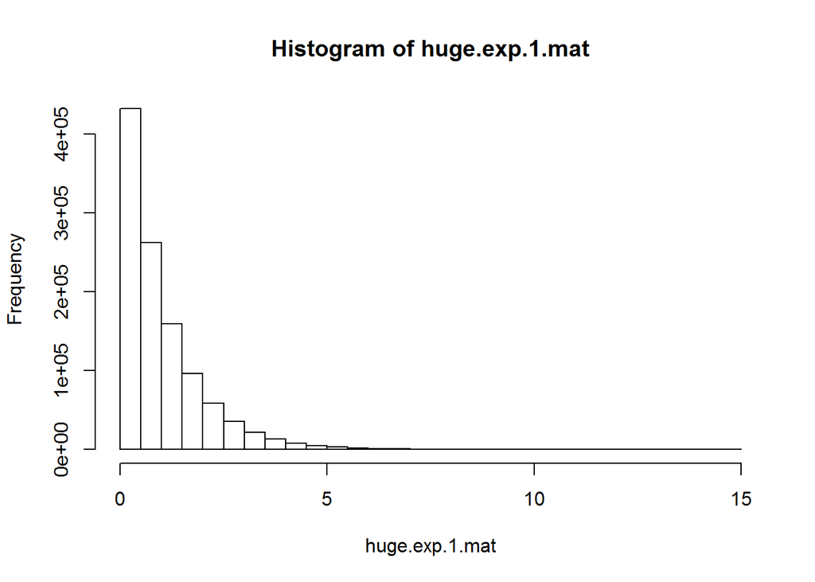

```r
huge.exp.1.mat = matrix(huge.exp.1, nrow = 1100, ncol = 1000)
hist(huge.exp.1.mat)
```

полученная гистограмма соответствует гистограмме выше

Рассчитайте среднее 137-й колонки из huge.exp.1.mat.

```r
mean(huge.exp.1.mat[,137])
```

```
## [1] 1.053136
```

Найдите среднее всей 1000 колонок и сохраните их в вектор. Отобразите диаграмму средних зннчений колонок.

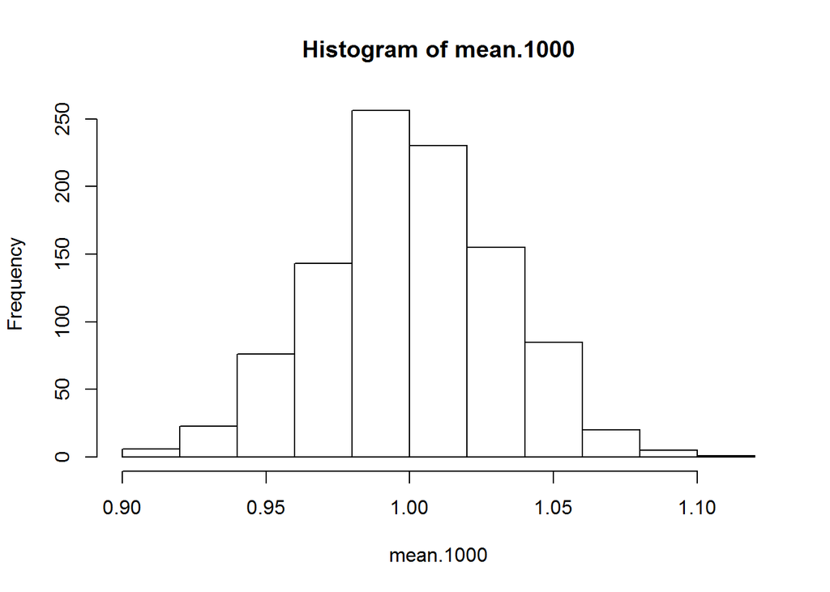

```r
colMeans(huge.exp.1.mat)->mean.1000
hist(mean.1000)
```

получили гистограмму, она имеет нормальное распределение

Рассчитайте квадрат каждого значения из huge.exp.1 и найдите среднее и стандартное отклонение полученного вектора квадратов.

```r
huge.exp.1**2->huge.exp.1.new
mean(huge.exp.1.new)
```

```
## [1] 1.999906
```

```r
sd(huge.exp.1.new)
```

```
## [1] 4.479404
```

получили среднее и стандартное отклонение